# Analyses speech coding over daylong recordings

# Instructions for use

If this is first time that you are running this script, change the redoALL parameter to T so that the first set of chunks, under generate main databases, is recalculated. Make sure you’ve created a directory inside dalohumacosp called derivedFiles, where the databases will be stored. (This folder is not pushed to github.)

# Generate main databases

## Reading in current results

New version of tg, compose

uses code from https://stackoverflow.com/questions/41839268/sum-overlapping-non-overlapping-time-intervals-in-r by Jonathan von Schroeder

```r
final_folder="~/owncloud/namvanj/"
csvs=dir(path=final_folder,pattern="csv")
all=NULL
for(thisf in csvs){
  #csvs[1]->thisf
  read.csv(paste0(final_folder,thisf))->thiscsv
  bits=strsplit(thisf,"_")
  if(dim(thiscsv)[1]==0) thiscsv[1,]<-NA
  all=rbind(all,cbind(thisf, bits[[1]][1],bits[[1]][2],bits[[1]][3],thiscsv))
}

names(all)<-c("File","child","date","chunkstart",   "beg",  "speakerID",     "type",    "end")

#tier name clean
all$speakerID=gsub("*","",all$speakerID,fixed=T)
all$speakerID=gsub(" ","",all$speakerID,fixed=T)
table(all$speakerID)
all$speakerID[all$speakerID == "Autre"]<-"Noise"
all$speakerID[all$speakerID == "FA2"]<-"FA3"
all$speakerID[all$speakerID == "FA1"]<-"FA2"
all$speakerID[all$speakerID == "MOT"]<-"FA1"
all$speakerID[all$speakerID %in% c("+2parl","2POPMT","2parlou+")]<-"XOL" #overlap bet 2 or more speakers hard to separate
all$speakerID[all$speakerID %in% c("LF2P","Loin","Loin-faible")]<-"SP" #far away speech, "second plane"
all$speakerID=gsub("^C","UC",all$speakerID,perl=T)
all$speakerID[all$speakerID %in% c("UCHI")]<-"CHI"
table(all$speakerID)

all$type[all$type=="1\177"]<-1
all$type[all$type=="xx"]<-"x"
all$type[all$type=="X"]<-"x"
all$type[all$type %in% c(" ","\177")]<-NA
all$type[all$type %in% c("1&","11")]<-"1"
table(all$type)

all$chunk=as.numeric(as.character(gsub(".csv","",all$chunk,fixed=T)))

all$dur=all$end-all$beg

all$recn=substr(all$date,9,9)

all$date=as.Date(paste(substr(all$date,1,4),substr(all$date,5,6),substr(all$date,7,8),sep="-"))

write.table(all,"../derivedFiles/line_per_segment.txt", row.names=F,quote=T,sep="\t")
```

## do summaries per child & file

```r
###### local functions
extract_interval_as_vector <- function(df) {
  as.vector(t(subset(df,select=c('beg','end'))))
}

sum_length <- function(v) {
  sum(v[seq(2,length(v),2)]-v[seq(1,length(v),2)])
}

sum_length_of_overlaps <- function(v1,v2) {
  id <- rep(c(1,0),c(length(v1),length(v2)))
  m <- rbind(id,1-id,c(v1,v2))
  m <- m[,order(m[3,])]
  idx <- which(cumsum(m[1,]) %% 2 & cumsum(m[2,]) %% 2)
  if(length(idx)) sum(sapply(idx,function(i) m[3,i+1]-m[3,i]))
  else 0
}

all_df=all[all$speakerID!="Noise" &    all$speakerID!="SP",]

sums=NULL
for(thisf in levels(all$File)){
  subset(all_df,File==thisf)->df
  all_names <- unique(df$speakerID)
  if(length(all_names)>1){
   # print(length(all_names>1))
    combs <- combn(all_names,2)
    for(i in 1:ncol(combs)) {
     df.sub1 <- subset(df,speakerID == combs[1,i])
     df.sub2 <- subset(df,speakerID == combs[2,i])
      int1= extract_interval_as_vector(df.sub1)
      int2= extract_interval_as_vector(df.sub2)
      l1 <- sum_length(int1) #sum(df.sub1$duration)
      l2 <- sum_length(int2) #sum(df.sub2$duration)
      ol=sum_length_of_overlaps(int1,int2)
      x=cbind(df[1,1:4],combs[1,i],l1, T)
      names(x)<-c(names(df)[1:4],"source","dur","clean")
      y=cbind(df[1,1:4],combs[2,i],l2, T)
      names(y)<-c(names(df)[1:4],"source","dur","clean")
      z=cbind(df[1,1:4],paste(combs[1,i],combs[2,i]),ol ,F)
      names(z)<-c(names(df)[1:4],"source","dur","clean")
      sums=rbind(sums, x,y,z)
    }
  } else{
    x=cbind(df[1,1:4],all_names[1],sum(df$dur),T)
    names(x)<-c(names(df)[1:4],"source","dur","clean")
    sums=rbind(sums, x)}
}

write.table(sums,"../derivedFiles/line_per_chunk.txt", row.names=F,quote=T,sep="\t")
```

## Add age info

move age adding above to all, so we don’t need to do it twice (for all, for sums).

```r
##PROBLEM!!! FOR SURE XOANAN IS AMBIGUOUS
#KXAO IS TOO (2 KIDS HAVE IT AS LAST NAME)
#GAKU NOT PRESENT
read.table("~/owncloud/namvanj/ages.text",header=T)->ages
cbind(stack(ages[,c(2:4)]),ages$shortname)->x
gsub("X","",x$ind)->x$ind
x[,3]=paste0(x[,2],x[,3])
x=x[,c(1,3)]
names(x)<-c("age","key")

all$key=paste0(substr(gsub("-","",all$date),1,6),all$child)
merge(all,x,all.x=F,all.y=F)->all

all$chidate=paste0(all$child,all$date)
all$chiage=paste0(all$child,all$age)

write.table(all,"../derivedFiles/line_per_segment_age.txt", row.names=F,quote=T,sep="\t")
```

```r
read.table("../derivedFiles/line_per_chunk.txt", header=T)->sums
sums$key=paste0(substr(gsub("-","",sums$date),1,6),sums$child)
merge(sums,x,all.x=F,all.y=F)->sums

write.table(sums,"../derivedFiles/line_per_chunk_age.txt", row.names=F,quote=T,sep="\t")
```

## Generating Proportion & quantities of CHI vocalizations of different types

```r
aggregate(all$dur,by=list(all$child,all$age,all$speakerID,all$type,all$date),sum,na.rm=T)->sumdur
names(sumdur)<-c("child","age","speakerID","type","date","totdur")
sumdur[sumdur$speakerID=="CHI" ,]->sumchi

sumchi$chidate=paste0(sumchi$child,sumchi$date)
sumchi[sumchi$type==0,c("chidate","totdur")]->chinonling
colnames(chinonling)[2]<-"nonling"
sumchi[sumchi$type==1,]->chiling
colnames(chiling)[dim(chiling)[2]-1]<-"ling"
merge(chiling,chinonling,all.x=T,all.y=T)->sumchi
sumchi$ling[is.na(sumchi$ling)]<-0
sumchi$nonling[is.na(sumchi$ling)]<-0
sumchi$tot=sumchi$ling+sumchi$nonling
sumchi$prop=sumchi$ling/sumchi$tot
sumchi$chag=paste0(sumchi$child,sumchi$age)

sumchi$nchunks=NA
for(eachchidate in levels(factor(all$chidate))) sumchi$nchunks[sumchi$chidate==eachchidate]<- length(levels(factor(all$File[all$chidate==eachchidate])))

sumchi$lingRatio=sumchi$ling/(sumchi$nchunks*60)
sumchi$nonlingRatio=sumchi$nonling/(sumchi$nchunks*60)


write.table(sumchi,"../derivedFiles/propling_age.txt",row.names=F,sep="\t")
```

## Generating Proportion & quantities of FA1 linguistic vocalizations

```r
aggregate(all$dur,by=list(all$child,all$age,all$speakerID,all$type,all$date),sum,na.rm=T)->sumdur
names(sumdur)<-c("child","age","speakerID","type","date","totdur")
sumdur[sumdur$speakerID=="FA1",]->summot

summot$chidate=paste0(summot$child,summot$date)
summot[summot$type==0,c("chidate","totdur")]->motnonling
colnames(motnonling)[2]<-"nonling"
summot[summot$type==1,]->motling
colnames(motling)[dim(motling)[2]-1]<-"ling"
merge(motling,motnonling,all.x=T,all.y=T)->summot
summot$ling[is.na(summot$ling)]<-0
summot$nonling[is.na(summot$ling)]<-0
summot$tot=summot$ling+summot$nonling
summot$prop=summot$ling/summot$tot
summot$chag=paste0(summot$child,summot$age)

summot$nchunks=NA
for(eachchidate in levels(factor(all$chidate))) summot$nchunks[summot$chidate==eachchidate]<- length(levels(factor(all$File[all$chidate==eachchidate])))

summot$lingRatio=summot$ling/(summot$nchunks*60)
summot$nonlingRatio=summot$nonling/(summot$nchunks*60)


write.table(summot,"../derivedFiles/propling_age_MOT.txt",row.names=F,sep="\t")
```

# Actual analyses

## Initial analyses: check 1

The goal of these initial analyses is to confirm strong predictions, as a way to validate the analyses.

First, how much do CHI and FAN vocalize as a function of CHI’s age?

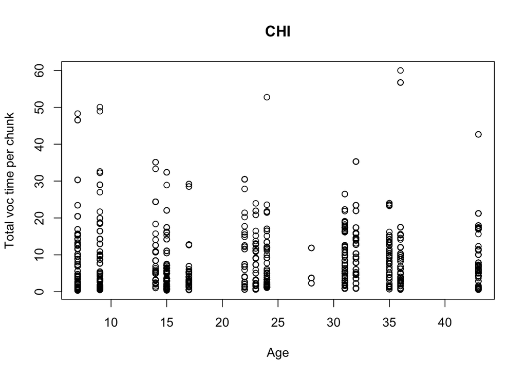

```r
read.table("../derivedFiles/line_per_chunk_age.txt", header=T)->sums

plot(sums$dur~sums$age,subset=c(sums$source=="CHI"),xlab="Age",ylab="Total voc time per chunk",main="CHI")
```

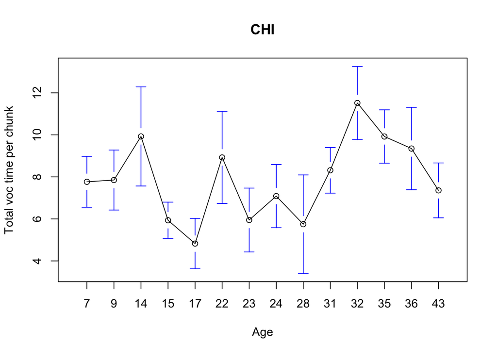

```r
library(gplots)
plotmeans(sums$dur~sums$age,subset=c(sums$source=="CHI"),xlab="Age",ylab="Total voc time per chunk",main="CHI",n.label = F)
```

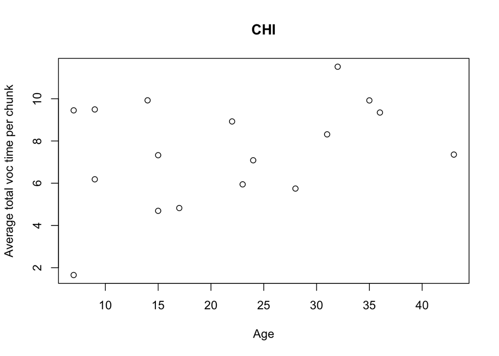

```r
aggregate(sums$dur,by=list(sums$source,sums$age,sums$child,sums$clean),mean)->means

names(means)<-c("source","age","child","clean","dur")

plot(means$dur~means$age,subset=c(means$source=="CHI" & means$clean),xlab="Age",ylab="Average total voc time per chunk",main="CHI")
```

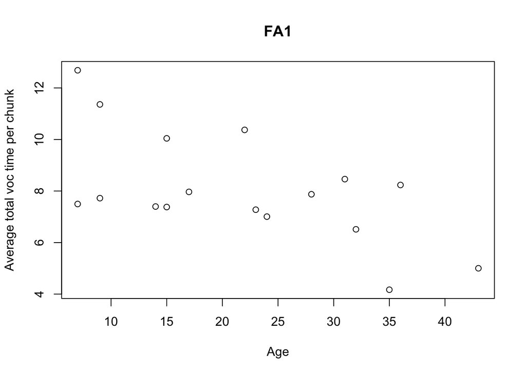

```r
plot(means$dur~means$age,subset=c(means$source=="FA1"& means$clean),xlab="Age",ylab="Average total voc time per chunk",main="FA1")
```

I had expected FA1 to vocalize MORE as children age, yet I observe the opposite. Perhaps that was not the right prediction to make? I also filtered (as the final code above shows) for clean (non-overlaps) only, and for FA1 this pattern is exacerbated.

I also expected CHI to vocalize MORE as they age, yet I observe no trend. This was a strong prediction that I am not willing to revise, and which instead makes me suspicious of the data. This may indicate that there is a bias to detect CHI regardless of age. One way that this suspicion could be lifted to a certain extent is the proportion of linguistic vocs going up with age. (Not totally, as the coder knew the age so could have been biased to hear more ling segments as a function of age.)

## Initial analyses: check 2

```r
dokidageplot<-function(sumchi,dvname,fancydvname){
  #dvname="prop";fancydvname="prop"
  plot(sumchi[,dvname]~sumchi$age,type="n",main=fancydvname,xlab="Age (months)",ylab=dvname)
for(kidag in levels(factor(sumchi$chag))){
  age=mean(sumchi$age[sumchi$chag==kidag],na.rm=T)
  prop=mean(sumchi[sumchi$chag==kidag,dvname],na.rm=T)
  err=sd(sumchi[sumchi$chag==kidag,dvname],na.rm=T)
  text(age,prop,substr(kidag,1,3))
  lines(c(age,age),c(prop-err,prop+err),col="gray")
}

for(kid in levels(factor(sumchi$child))){
  props = aggregate(sumchi[sumchi$child==kid,dvname],by=list(sumchi$age[sumchi$child==kid]),mean,na.rm=T)
  for(thisline in 1:(dim(props)[1]-1)) lines(c(props$Group.1[thisline],props$Group.1[thisline+1]),c(props$x[thisline],props$x[thisline+1]),lty=2)
}

    plot(sumchi[,dvname]~sumchi$age,cex=(sumchi[,dvname]/max(sumchi[,dvname],na.rm=T)),main="Data per recording day",xlab="Age (months)",ylab=dvname)
text(sumchi$age,sumchi[,dvname],as.character(sumchi$child),cex=.5,pos=4)

}
```

Strong prediction that should be verified: higher proportion of ling as kids age.

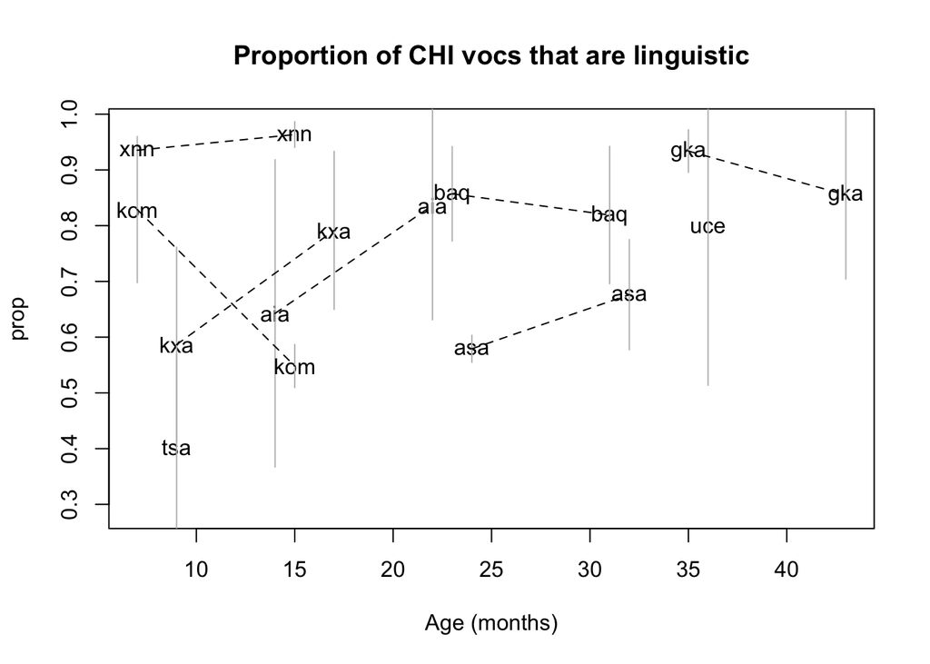

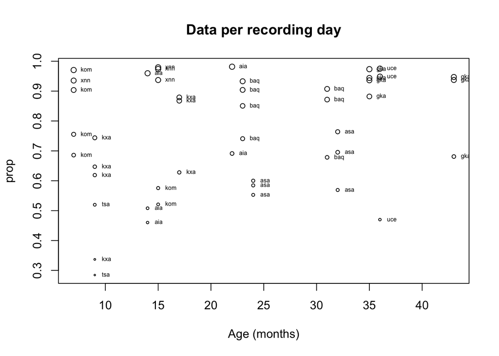

```r
read.table("../derivedFiles/propling_age.txt", header=T)->sumchi


dokidageplot(sumchi,"prop","Proportion of CHI vocs that are linguistic")
```

So these results are more encouraging, although as mentioned above it could be due to the coder’s expectations…

Above we looked at proportion of linguistic over all child vocalizations. Does this go up because linguistic voc quantity goes up with age, or because non-ling goes down? I predicted both of these were true.

First we look at quantity of linguistic vocalizations, controlling for recording length. That is, these are proportions of the time that has been coded where CHI produces ling vocs. For instance, if kid produced 200 secs of ling vocalizations in a given day, of which 1000 secs have been coded, then they will show up below as .2. The graphs below suggest that quantity of ling vocs increases with CHI age.

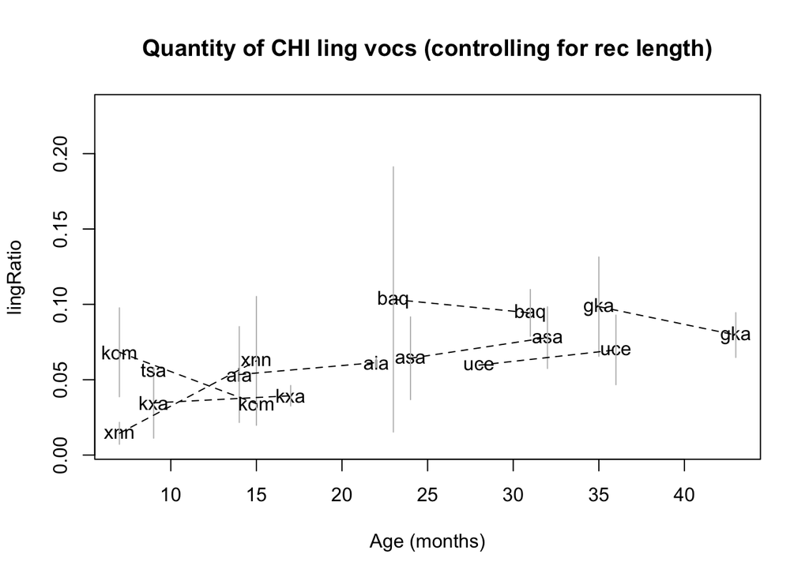

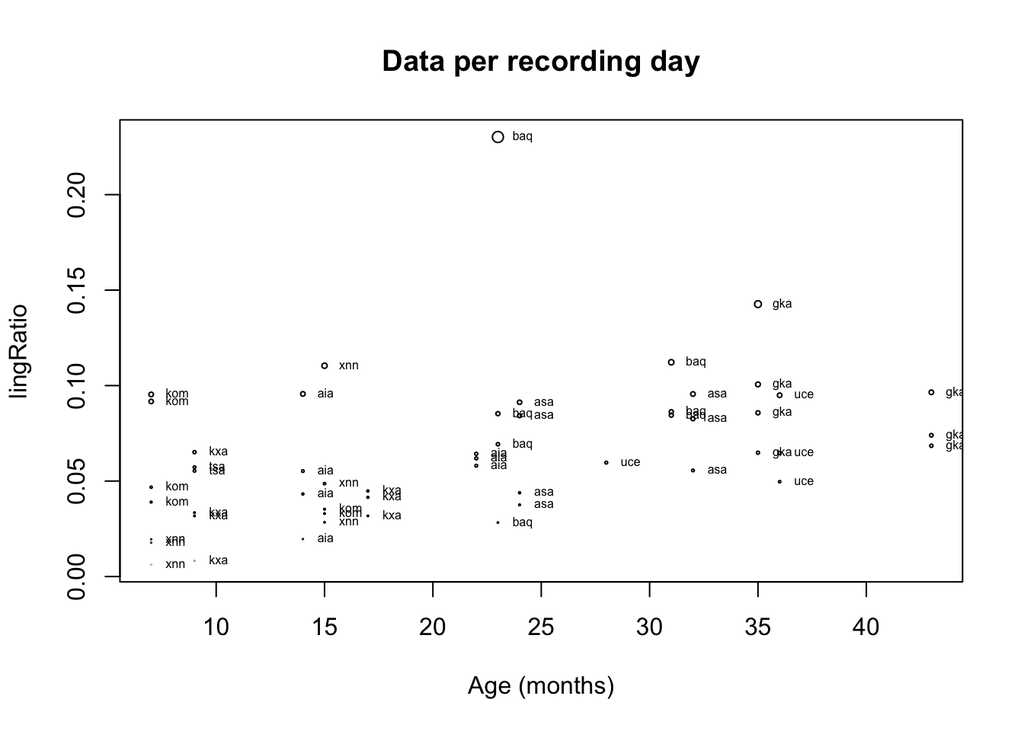

```r
dokidageplot(sumchi,"lingRatio","Quantity of CHI ling vocs (controlling for rec length)")
```

Now the same types of calculations but on non-ling vocs. The graphs below do not suggest a massive reduction of quantity of non-ling vocs with CHI age.

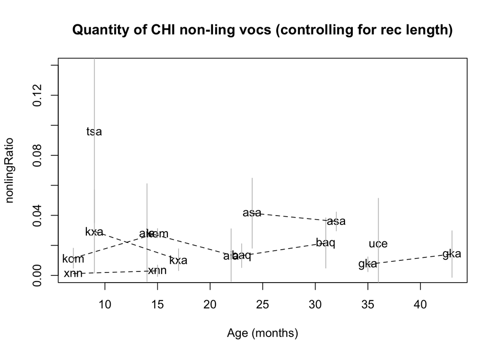

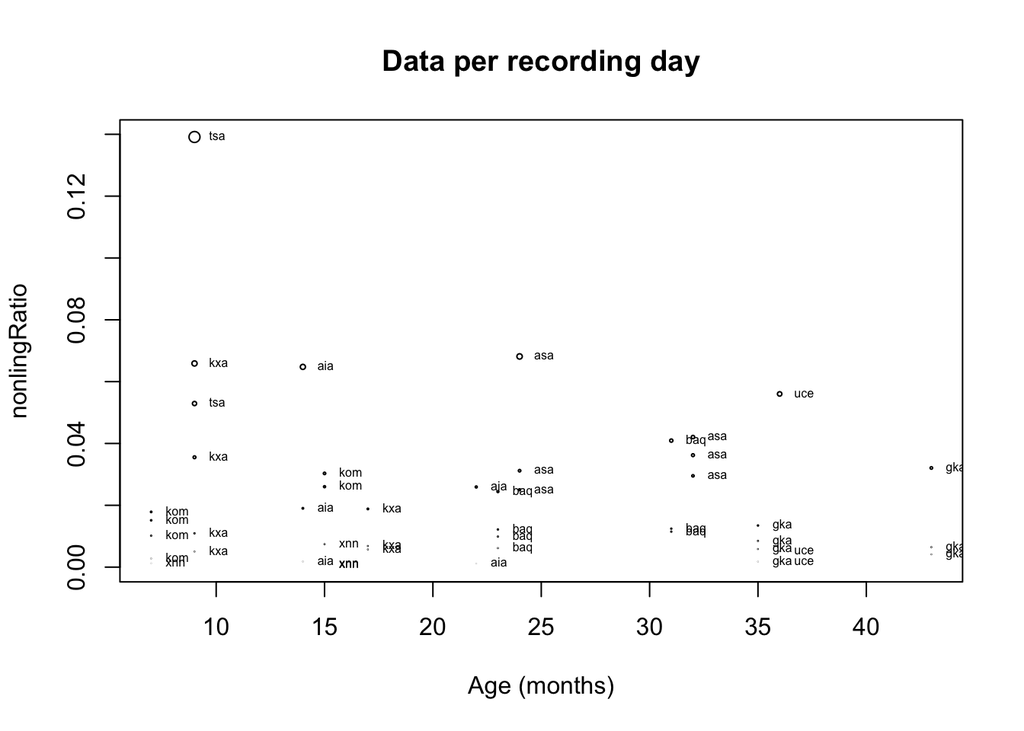

```r
dokidageplot(sumchi,"nonlingRatio","Quantity of CHI non-ling vocs (controlling for rec length)")
```

## Check 3: Stability in CHI vocal behavior over days

We often recorded 3 days – how stable is vocal behavior across days within the same participant (CHI only for now)?

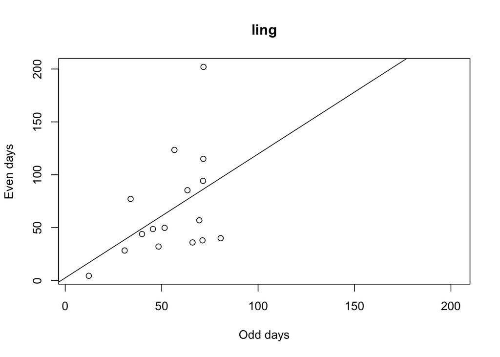

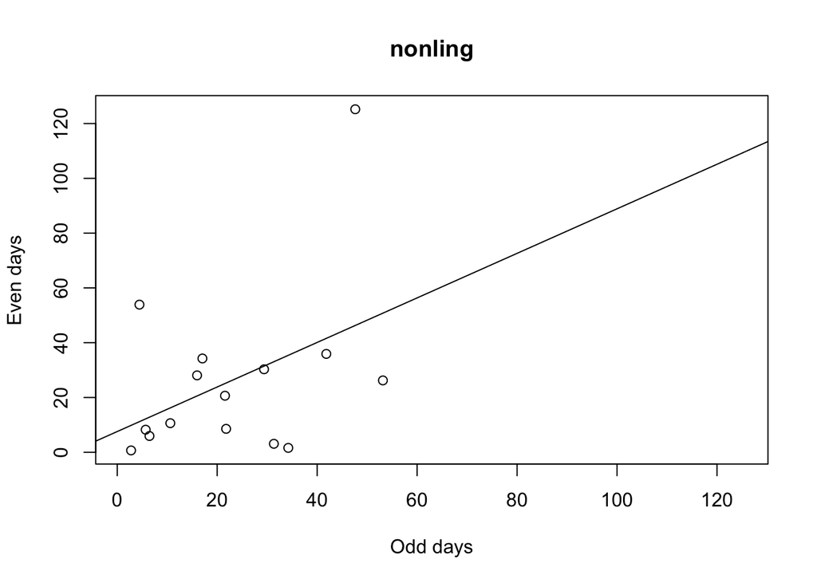

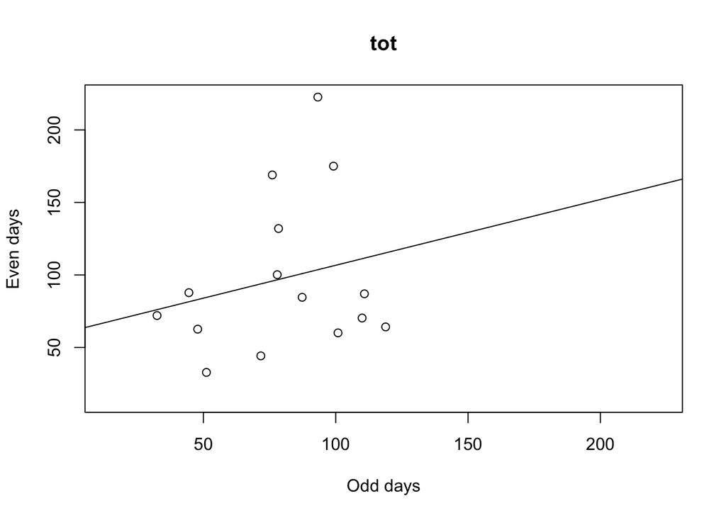

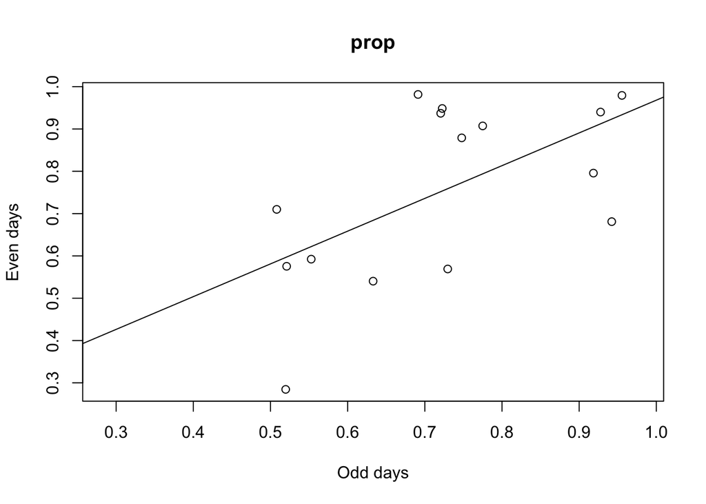

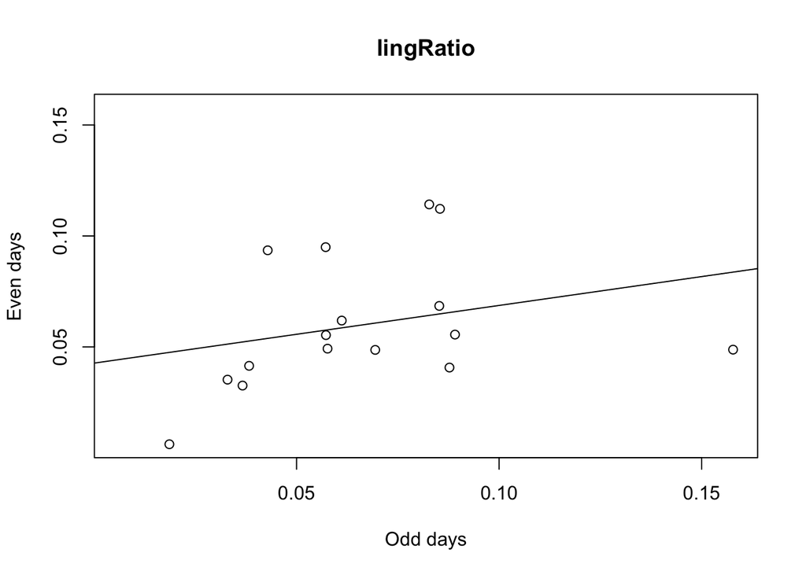

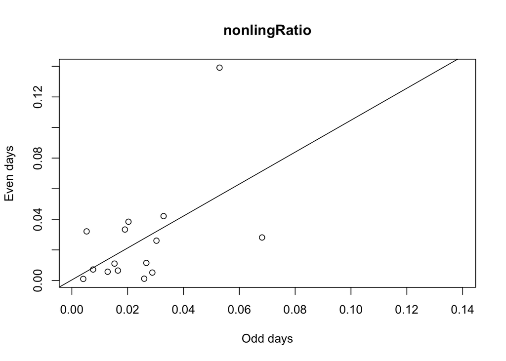

```r
read.table("../derivedFiles/propling_age.txt", header=T)->sumchi

twodays=NULL
for(eachkid in names(table(sumchi$chag))[table(sumchi$chag)>1]){
  subset(sumchi,chag==eachkid)->thischidat
  odd_days=cbind(thischidat[1,c("child","age","chag")],
             t( colMeans(thischidat[seq(1,dim(thischidat)[1],by=2),c("ling","nonling","tot","prop","lingRatio","nonlingRatio")],na.rm=T)),
              sum(thischidat[seq(1,dim(thischidat)[1],by=2),c("nchunks")],na.rm=T),1)
  names(odd_days)[10:11]<-c("nchunks","day")

   even_days=cbind(thischidat[1,c("child","age","chag")],
             t( colMeans(thischidat[seq(2,dim(thischidat)[1],by=2),c("ling","nonling","tot","prop","lingRatio","nonlingRatio")],na.rm=T)),
              sum(thischidat[seq(2,dim(thischidat)[1],by=2),c("nchunks")],na.rm=T),2)
  names(even_days)[10:11]<-c("nchunks","day")
    twodays=rbind(twodays, odd_days,even_days )
}

for(thisdv in c("ling","nonling","tot","prop","lingRatio","nonlingRatio")){
  temp=table(twodays$chag[!is.na(twodays[,thisdv])])
  goodkids=names(temp)[temp==2]
  plot(twodays[twodays$day==2 & twodays$chag %in% goodkids,thisdv]~twodays[twodays$day==1 & twodays$chag %in% goodkids,thisdv],xlab="Odd days",ylab="Even days", main=thisdv,xlim=range(twodays[,thisdv],na.rm=T),ylim=range(twodays[,thisdv],na.rm=T))
abline(lm(twodays[twodays$day==2,thisdv]~twodays[twodays$day==1,thisdv]))
cor.test(twodays[twodays$day==2,thisdv],twodays[twodays$day==1,thisdv],method="s")
}
```

Weak correlation, not super convincing.

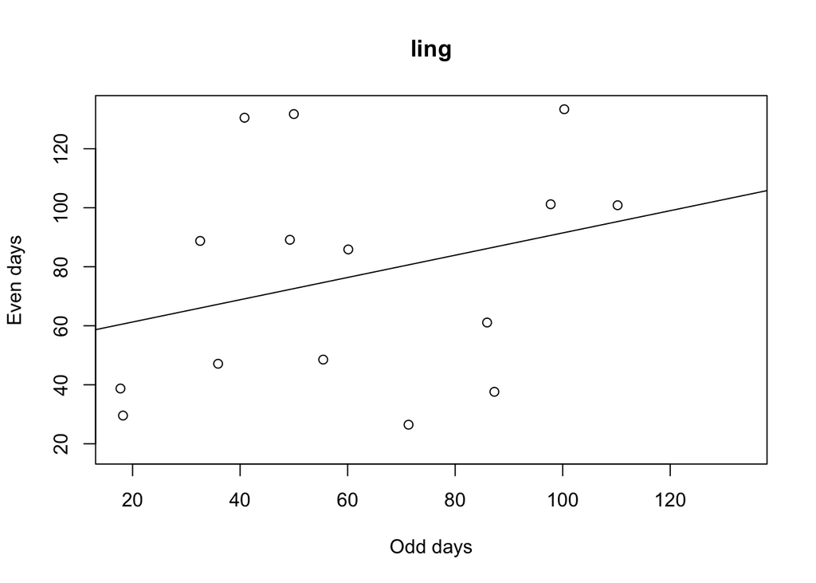

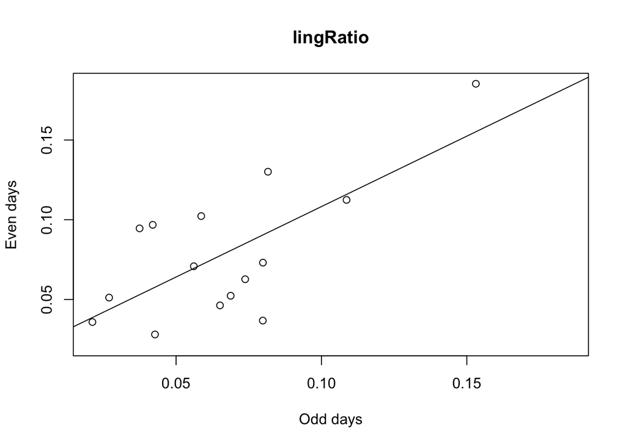

```r
read.table("../derivedFiles/propling_age_MOT.txt", header=T)->summot

twodays=NULL
for(eachkid in names(table(summot$chag))[table(summot$chag)>1]){
  subset(summot,chag==eachkid)->thischidat
  odd_days=cbind(thischidat[1,c("child","age","chag")],
                 t( colMeans(thischidat[seq(1,dim(thischidat)[1],by=2),c("ling","nonling","tot","prop","lingRatio","nonlingRatio")],na.rm=T)),
                 sum(thischidat[seq(1,dim(thischidat)[1],by=2),c("nchunks")],na.rm=T),1)
  names(odd_days)[10:11]<-c("nchunks","day")

  even_days=cbind(thischidat[1,c("child","age","chag")],
                  t( colMeans(thischidat[seq(2,dim(thischidat)[1],by=2),c("ling","nonling","tot","prop","lingRatio","nonlingRatio")],na.rm=T)),
                  sum(thischidat[seq(2,dim(thischidat)[1],by=2),c("nchunks")],na.rm=T),2)
  names(even_days)[10:11]<-c("nchunks","day")
  twodays=rbind(twodays, odd_days,even_days )
}

for(thisdv in c("ling","lingRatio")){
  temp=table(twodays$chag[!is.na(twodays[,thisdv])])
  goodkids=names(temp)[temp==2]
  plot(twodays[twodays$day==2 & twodays$chag %in% goodkids,thisdv]~twodays[twodays$day==1 & twodays$chag %in% goodkids,thisdv],xlab="Odd days",ylab="Even days", main=thisdv,xlim=range(twodays[,thisdv],na.rm=T),ylim=range(twodays[,thisdv],na.rm=T))
  abline(lm(twodays[twodays$day==2,thisdv]~twodays[twodays$day==1,thisdv]))
  cor.test(twodays[twodays$day==2,thisdv],twodays[twodays$day==1,thisdv],method="s")
}
```

# new ideas :

- name of the key child in vocative or not crossing across ages / across days (& the interaction) with the following dependent measures:
- identity of people around the child; their number, and their contribution to overall quantity
- CHI. voc auqntm speech auqntm ratio
- mot talk quant
- chi-mot correlation All of the above can be done over siblings in the Tsi dataset
- expect more speech at day than night; describe quant over hours –> do we have hours?